# Part II - DATA ANALYSIS ON THE PISA DATASET

## by (Igweze Ifeanyi)

## Investigation Overview

> From my EDA I uncovered what I choose to call an anomaly, the fact though students perfom better with their parents, the more time they spend the less their scores are. Due to the negative correlation I choose to focus my slides on this, showing a bivariate and multivariate visualization demonstrating the relationship between the variables.

## Dataset Overview

> This is a dataset which examines how well students have learned the school curricullum and how well prepared they are for life beyond school, all from 510,000 students in 65 economies took part in the PISA 2012 assessment of reading, mathematics and science. Of those economies, 44 took part in an assessment of creative problem solving and 18 in an assessment of financial literacy. During wrangling I removed null values, took away columns I had no use of, renamed some columns, calculated and created the average column etc.

## (Visualization 1)

### How much time does the parent spend working with the student?

Here I wanted to know how much time parents give their children, as it may lead to better scores.

**Inference:**

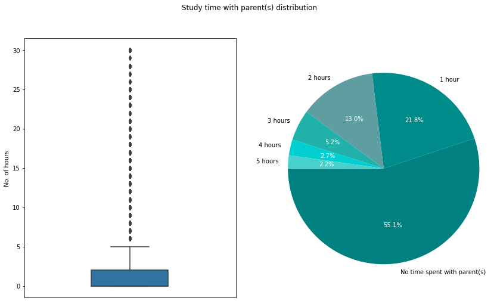

## (Visualization 2)

### Parent Presence vs Score

Then I went further to chech whether students perform better having both parents or just a single parent.

**Inference:**

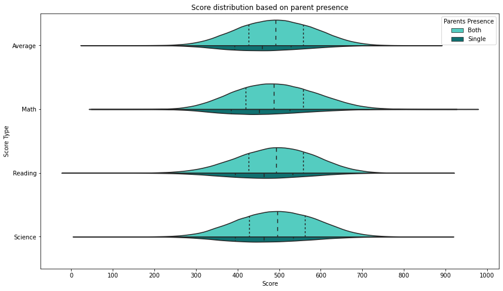

## (Visualization 3)

### Parents presence vs Score vs Time spent with parents

To confirm and accurately postulate students perform better with attention from both parents, I decided to analyse all variables in the same visualization.

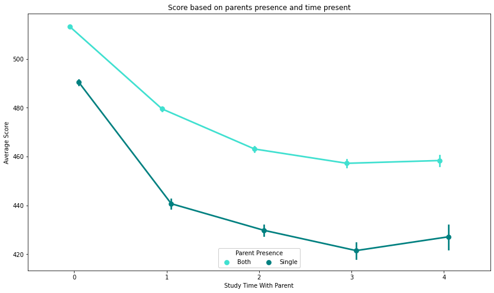